# Discernibility and Randomization Distributions

Day 15

Claire Kelling

Carleton College  
STAT 120 - Fall 2026

## Today’s Topics

Housekeeping:

- Final project group preferences form closes this evening!
- Midterm Evaluation form due this evening
- Come to Office Hours with questions about Homework 5!

Topics covered today:

- Statistical Discernibility
- Randomization Distribution

# “Statistically Discernible”

## Statistically Discernible

When results as extreme as the observed sample statistic are unlikely to occur by random chance alone (assuming the null hypothesis is true), we say the sample results are **statistically discernible**

- If our sample is **statistically discernible**, we have convincing evidence against $H_0$, in favor of $H_a$
  - “We reject the null hypothesis”
- If our sample is **not statistically discernible**, our test is **inconclusive**. The null hypothesis may be true (or maybe not)
  - “We fail to reject the null hypothesis.”

## ESP Example (Revisit)

$p$ = proportion of correct guesses

- $H_0$: $p = 1/5$
- $H_a$: $p > 1/5$

If the results **are statistically discernible:**

- the sample proportion of correct guesses is **higher** than what is likely just by random chance (if ESP does not exist and p = 1/5)
- we have evidence that the true proportion of correct guesses really is **higher than 1/5**, and thus have evidence of ESP

## ESP Example (Revisit)

$p$ = proportion of correct guesses

- $H_0$: $p = 1/5$
- $H_a$: $p > 1/5$

If the results **are NOT statistically discernible:**

- the sample proportion of correct guesses could easily happen just by random chance (if ESP does not exist and p = 1/5)
- we do not have enough evidence to conclude that p > 1/5, or that ESP exists
- BUT **we still can’t say that p = 1/5**

## Sleep vs Caffeine Revisit

**Context**

- $\mu_s$ and $\mu_c$: mean number of words recalled after sleeping and after caffeine
- $H_0$: $\mu_s = \mu_c$, $H_a$: $\mu_s \neq \mu_c$
- The sample difference in means is $\bar{x}_s - \bar{x}_c = 3$, and this is **statistically discernible**.

From this, we can conclude… (circle one)

1. there is a (statistical) difference between sleep and caffeine for memory **Correct!**
2. there is not a difference between sleep and caffeine for memory
3. inconclusive results

## Sleep vs Caffeine Revisit

**Context**

- $\mu_s$ and $\mu_c$: mean number of words recalled after sleeping and after caffeine
- $H_0$: $\mu_s = \mu_c$, $H_a$: $\mu_s \neq \mu_c$
- The sample difference in means is $\bar{x}_s - \bar{x}_c = 3$, and this is NOT **statistically discernible**.

From this, we can conclude… (circle one)

1. there is a (statistical) difference between sleep and caffeine for memory
2. there is not a difference between sleep and caffeine for memory
3. inconclusive results **Correct!**

## How do we determine this?

- How do we determine if a result is statistically discernible??
- For ESP example:
  - If **there is no ESP**, how unusual would it be to get 3 correct guesses in 10 tries?
- For Sleep versus Caffeine example:
  - If **the effects of sleep and caffeine on recall are the same**, how rare would it be to get an average difference of 3 words in the experiment conducted?
- We assess this with a probability that we call a “p-value.”

## Note on “Statistical Significance”

- In your readings (news, journals, etc), you may see the term “**statistically significant**.”
- We have been using the phrase “statistically discernible” instead.
- People often misinterpret the word “significance” to mean (**scientifically**) important.
- There is a push by the statistics community to drop “statistically significant” in favor of “discernible”.

## Summary

- Statistical tests use data from a **sample** to assess a claim about a **population**
- Statistical tests are usually formalized with competing hypotheses:
  - Null hypothesis ($H_0$): no effect or no difference
  - Alternative hypothesis ($H_a$): what we seek evidence for
  - **A hypothesis is always a statement about a population parameter!
- If data are statistically discernible, we have convincing evidence against the null hypothesis, and in favor of the alternative
- If data are NOT statistically discernible, we fail to reject the null hypothesis

## Key Question

How unusual is it to see a sample statistic as extreme as that observed, if $H_0$ is true?

# Randomization Distribution

## ESP Example 1

$p$ = proportion of correct guesses

- $H_0$: $p = 1/5$
- $H_a$: $p > 1/5$
- Suppose we try this n=10 times and get 3 correct guesses.
- What kinds of statistics (sample proportions) would we observe just by chance, if the null were true and ESP does not exist?
- How can we generate this distribution?

Simulate many samples of size n=10 with p= 1/5 and look at the distribution of sample proportions.

## Randomization Distribution

**Definition**

A **randomization distribution** is a collection of statistics from samples simulated assuming the *null hypothesis is true.*

- Also known as a **permutation** distribution.
- A randomization distribution is centered at the **null hypothesis parameter value**.

## Randomization Distribution for ESP

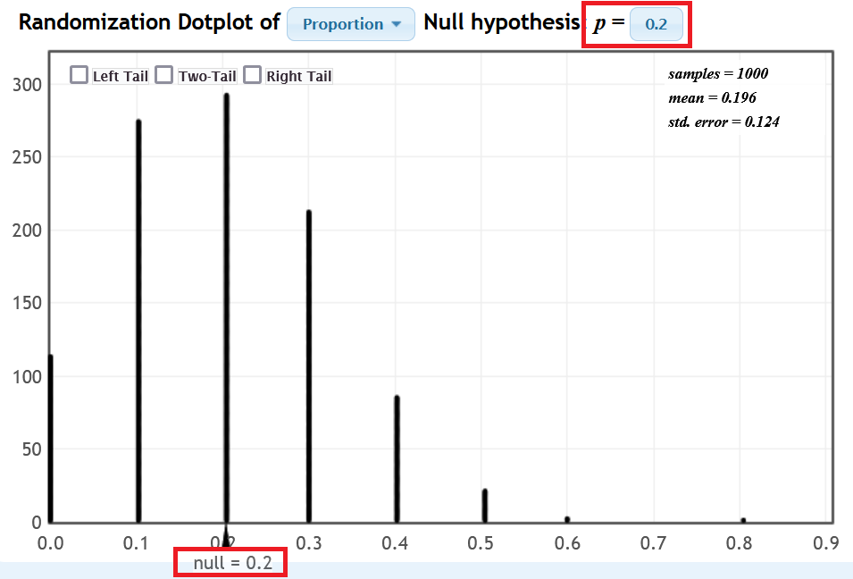

- $H_0: p = 1/5 = 0.2$
- Create many simulated samples ($n=10$) under the null hypothesis
- Proportion cards guessed correctly when there is **no ESP** ($H_0$)

## Return to Key Question

How unusual is it to see a sample statistic as extreme as that observed, if $H_0$ is true?

## P-value

**Definition**

The p-value is the chance of obtaining a sample statistic as extreme (or more extreme) than the observed sample statistic, if the null hypothesis is true

- The p-value can be calculated as the proportion of statistics in a randomization distribution that are **as extreme (or more extreme) than the observed sample statistic**
- “extreme” is determined by the **alternative** hypothesis
- How would I calculate my p-value from the previous randomization distribution, if $\hat{p} = 0.3$?

## Randomization Distribution for ESP

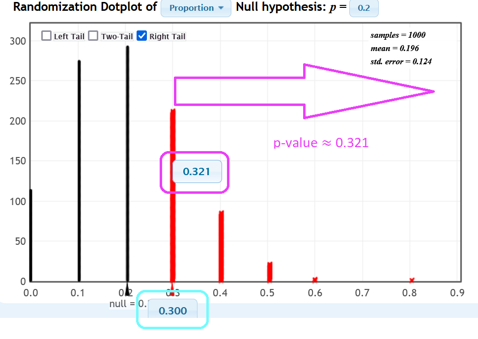

- $H_0: p = 1/5 = 0.2$
- $\hat{p} = 3/10 = 0.3$

## P-value for ESP

**P-value Interpretation**

The p-value is the chance of getting at least 3 out of 10 guesses correct, if p = $\frac{1}{5} =$ 0.2.

- P-value is about 0.321 (from randomization distribution)
- **Interpretation:** About 32% of the time we would get at least 3 out 10 guesses correct just by chance (no ESP).

**Conclusion**

What **conclusion** can we make given this p-value?

- **Inconclusive**, little evidence that supports ESP ($H_a$)

## Decision-making with p-values

- If the **p-value is small**, then a statistic as extreme as that observed would be unlikely if the null hypothesis were true, providing evidence against $H_0$ and **in favor of the alternative**

**Small p-value**

- Results are statistically discernible
- Reject the null in favor of the alternative

**Large p-value**

- Results are not statistically discernible
- Do not (we fail to) reject the null in favor of the alternative

What is small vs large? Next Class!

## ESP p-value Example: $n=5$

Use the randomization distribution below to test:

$H_0: p = 1/5$ $H_a: p > 1/5$

- Randomization distribution includes statistics (from samples of size $n=5$) simulated from the **null hypothesis.**
- Did any of you have statistically discernible ESP?
- (Beware of multiple testing! More on this later…)

For a **sample statistic** of $p = \frac{3}{5} = 0.6$, the **p-value** is 0.025

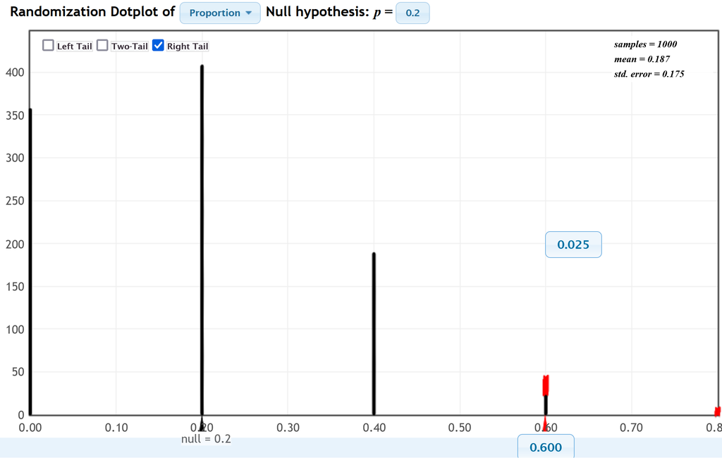

Randomization Distribution (under $H_0$)

# Carleton Basketball

## Carleton Basketball, 2022-2023

- Men’s basketball team had an incredible 22 - 3 conference record
- When the Knights played at **home**, they scored, on average, 7 points more than their opponents.
- When the Knights were **away**, they scored, on average, 10.8 points more than their opponents.

**Question**

Is this difference of performing better away real (reflecting something systematic), or could it just be due to natural variability?

## Carleton Basketball Hypotheses

- We are interested in the *point spread* between the two teams (Knights $-$ Opponents), so we are interested in **means**
- Let $\mu_A =$ true average spread of points for **away** games.
- Let $\mu_H =$ true average spread of points for **home** games
- **Question:** Are Carleton College students winning by bigger margins away from home? Is this a real difference (reflecting something systematic), or could it just be due to natural variability?

**Hypotheses**

**Null Hypothesis:**

$H_0: \mu_A = \mu_H$

**Alternative Hypothesis:**

$H_a: \mu_A > \mu_H$

## Carleton Basketball Data

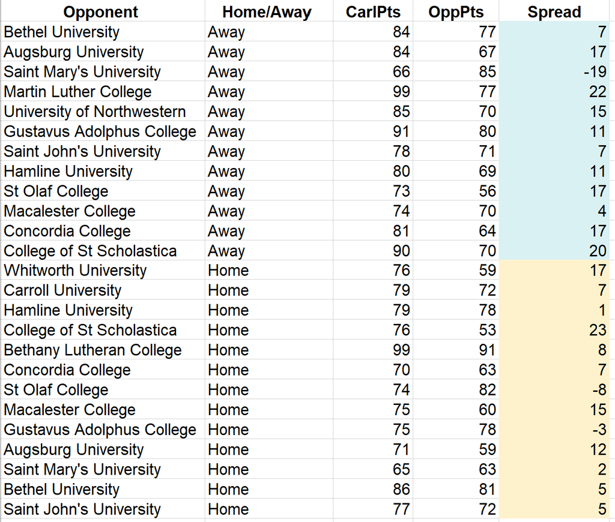

## Carleton Basketball Null Hypothesis

$$H_0: \mu_A = \mu_H$$

Suppose there really is **no** advantage playing away — in particular then, there really is no difference in the mean point spread in home games and away games.

## Carleton Basketball

**If there is no advantage to being away, the distribution of spreads which occurred, shown below**

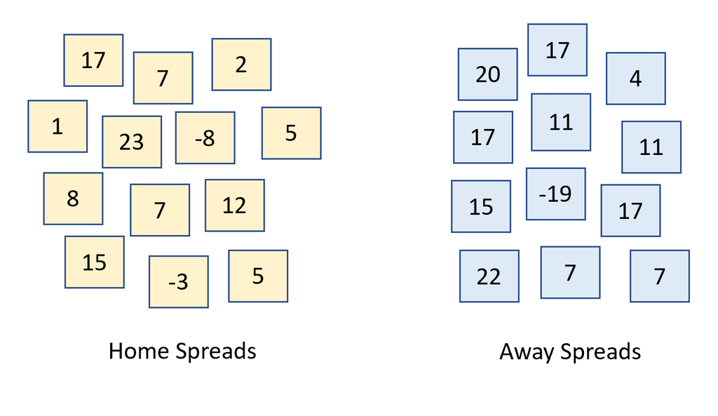

$\bar{x}_A = 10.8$, $\bar{x}_H = 7$ so $\bar{x}_A - \bar{x}_H = 3.8$ (observed sample statistic)

**could just as easily have been:**

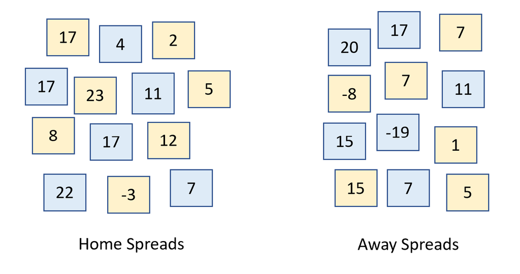

This is called a resample.

## Simulation in Groups

1. Put each spread value on a card (25 cards in total)- **done for you**
2. Obtain a resample by shuffling all of the cards and randomly distributing 13 cards to the Home game group and 12 cards to the Away game group
3. Find the mean of the spread for Home and the mean spread for Away and compute the difference (mean Away - mean Home, $\bar{x}_A - \bar{x}_H$).
4. Record this difference.
5. Repeat two times per group.

```r
mean(c(4,6,7,1,4,2,4,2,3,15))
```

When we repeat many times, we obtain a permutation (randomization) distribution of the mean difference.

## Simulation

- Recall that the **observed mean** spread was 3.8
- How unusual is this value, $\bar{x}_A - \bar{x}_H$ = 3.8, compared to the test statistics we obtained in the simulation?
- (Ideally we want more than 30 samples…)

## P-value, Basketball

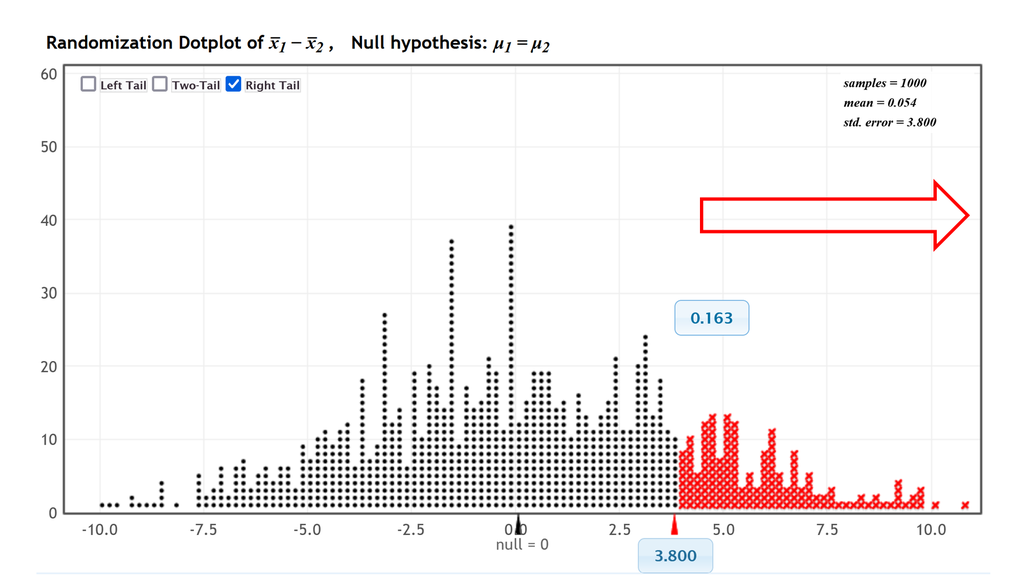

- Look at those resamples as or more extreme than observed 3.8
- What is the p-value for our class distribution?
- What about a distribution with a larger number of simulated examples?
- 163 resamples result in test statistics as large or larger than 3.8
- p-value = 163/1000 = 0.163

## Interpretation

- If there is no difference in point spreads between home and away game—that is, playing away from home confers no advantage—then **16.3% of resamples** would result in a mean difference as large or larger than the observed $\bar{x}_A - \bar{x}_H$ = 3.8.
- Thus, we conclude that the observed mean difference, $\bar{x}_A - \bar{x}_H$ = 3.8, is *reasonably likely* to be due to chance: the Knights advantage of playing away in terms of point spread is **not statistically discernible**.
- **Decision:** We fail to reject the null hypothesis. Our test is **inconclusive**.

## Next Class

- Practice in R for permutation tests for correlation and paired data
- What is our cutoff? (Significance levels)